# 12_Intro to Confidence Intervals

## Housekeeping

Make sure to get dataset to me for approval by tomorrow.

# Lecture

```r
library(tidyverse); library(ggsci)
```

Big Problem: We have limited data (a sample) about a population, but we still want to make (infer) conclusions about that population. How can we do that?

What are statistics vs parameters?

What’s the probability of a value being more than 4 standard deviations below the mean? First, where’s 1 SD on this plot?

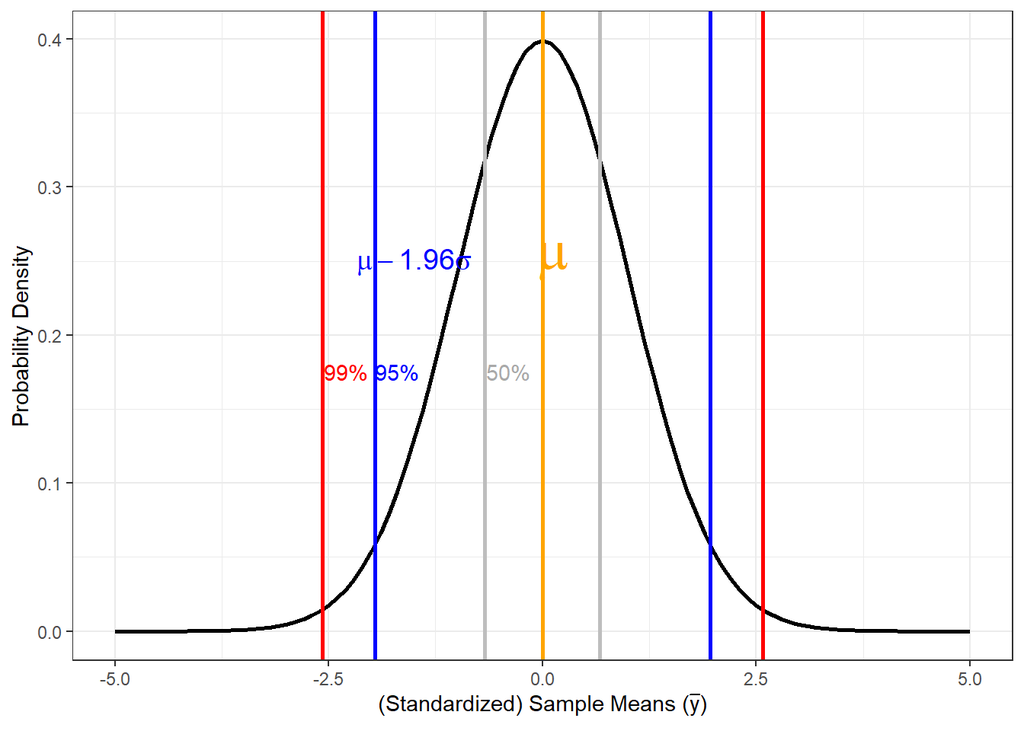

`pnorm()` calculates the cumulative probability (area) under the curve (to the left)

```r
pnorm(1.96)-pnorm(-1.96)
```

```
[1] 0.9500042
```

```r
1-pnorm(4)-pnorm(-4)
```

```
[1] 5.421011e-20
```

`qnorm()` calculates the boundary x (aka z if standard normal distribution) value from the distribution where a given area under the curve (probability) ends.

```r
qnorm(0.025)
```

```
[1] -1.959964
```

```r
qnorm(0.975)
```

```
[1] 1.959964
```

How do we know the distribution of a sample statistic calculated from our data?

## Confidence intervals

Recall that 95% of values in a normal distribution fall between $\mu - 1.96\sigma$ and $\mu + 1.96\sigma$. Recall that this is a statement about probability.

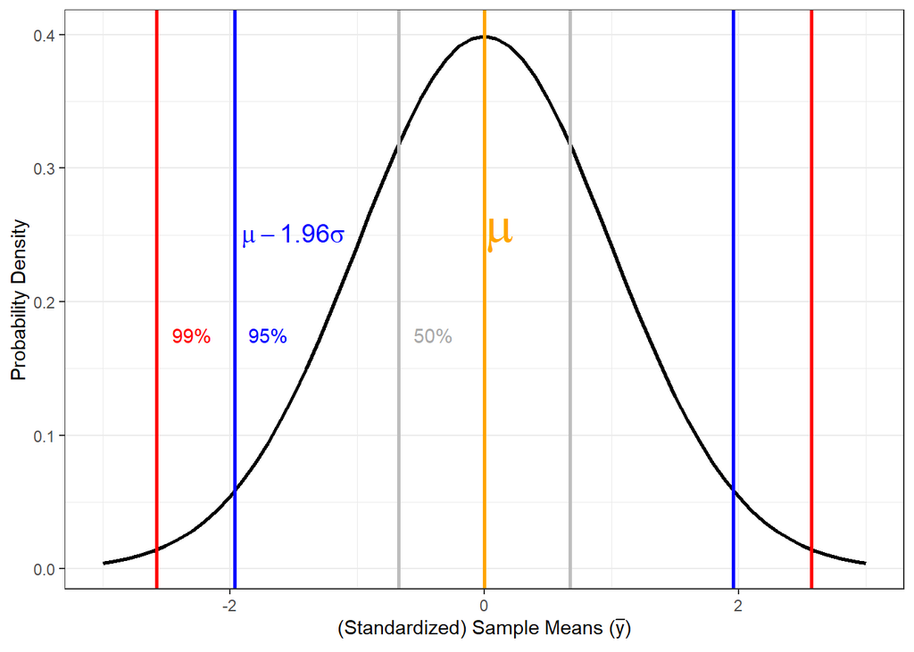

We can use this to make interval statements regarding the uncertainty of our population mean by calculating values between which a percentage of means occur. So,

$P(\bar{y} - 1.96\sigma_\bar{y}\le \mu \le \bar{y}-1.96\sigma_\bar{y}) = 0.95$. The problem?

$\sigma_\bar{y} = \frac{\sigma}{\sqrt{n}}$ and we usually don’t know $\sigma$ to calculate it. Why don’t we know it?

We can only *estimate* the standard deviation of the sample means with the standard error of the mean as $s_\bar{y}=\frac{s}{\sqrt{n}}$ where $s$ is the sample standard deviation (the square root of the sample variance). This means our standardized sample means are $\frac{\bar{y} - \mu}{s_\bar{y}}$. t distributions describe these variables.

The proper CI for $\mu$ is $P(\bar{y} - t_{0.025(n-1)}s_\bar{y}\le \mu \le \bar{y} + t_{0.025(n-1)}s_\bar{y}) = 0.95$. where $\pm t_{0.025(n-1)}$ is the value from the $t$ distribution with $n-1$ degrees of freedom between which 95% of all $t$ values lie.

The t distribution varies with sample size - more specifically the ‘degrees of freedom’ (df) that control it shape. As n increases above ~30, the t distribution will be very close to the normal.

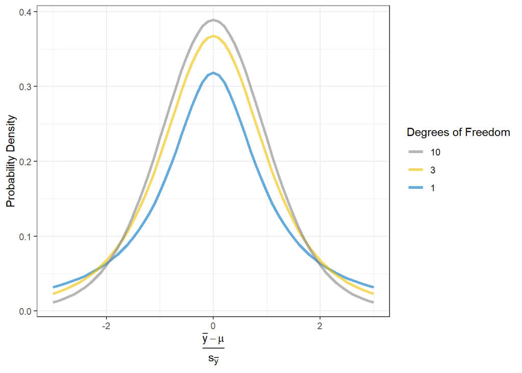

```r
df <- 2
tibble(Y = seq(-3,3, by = 0.1))|>expand_grid(df = c(1,3,10))|>mutate(Probability = dt(Y, df = df), df = as_factor(df))|>as_tibble()|>
  ggplot(aes(x = Y, y = Probability, color = df))+
  geom_line(linewidth = 1.25, alpha = 0.6)+
  scale_color_jco()+
  guides(color = guide_legend(title = "Degrees of Freedom", reverse = TRUE))+
  ylab("Probability Density")+xlab(expression(frac(bar(y) - mu, s[bar(y)])))+
  theme_bw()
```

CIs increase with decreasing sample size. Intuitive, but why mathematically?

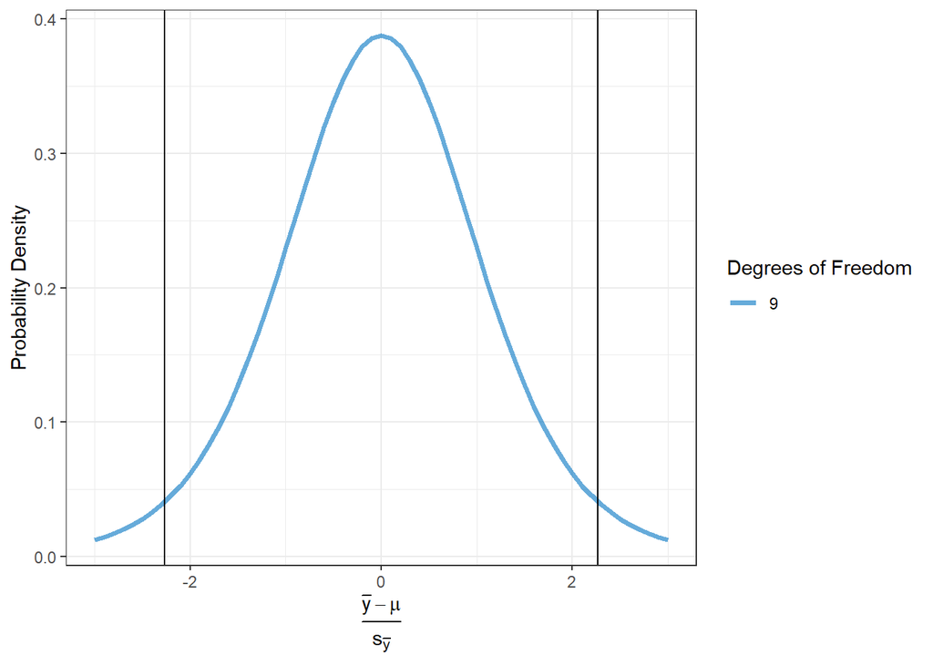

```r
n <- 10
df <- n-1
lower_95 <- qt(p = 0.025,df = df)
upper_95 <- qt(p = 0.975,df = df)
tibble(Y = seq(-3,3, by = 0.1))|>expand_grid(df = df)|>mutate(Probability = dt(Y, df = df), df = as_factor(df))|>as_tibble()|>
  ggplot(aes(x = Y, y = Probability, color = df))+
  geom_line(linewidth = 1.25, alpha = 0.6)+
  scale_color_jco()+
  geom_vline(aes(xintercept = upper_95))+
  geom_vline(aes(xintercept = lower_95))+
  guides(color = guide_legend(title = "Degrees of Freedom", reverse = TRUE))+
  ylab("Probability Density")+xlab(expression(frac(bar(y) - mu, s[bar(y)])))+
  theme_bw()
```

Where is 95% of mass in a standard normal distribution, between what two values?

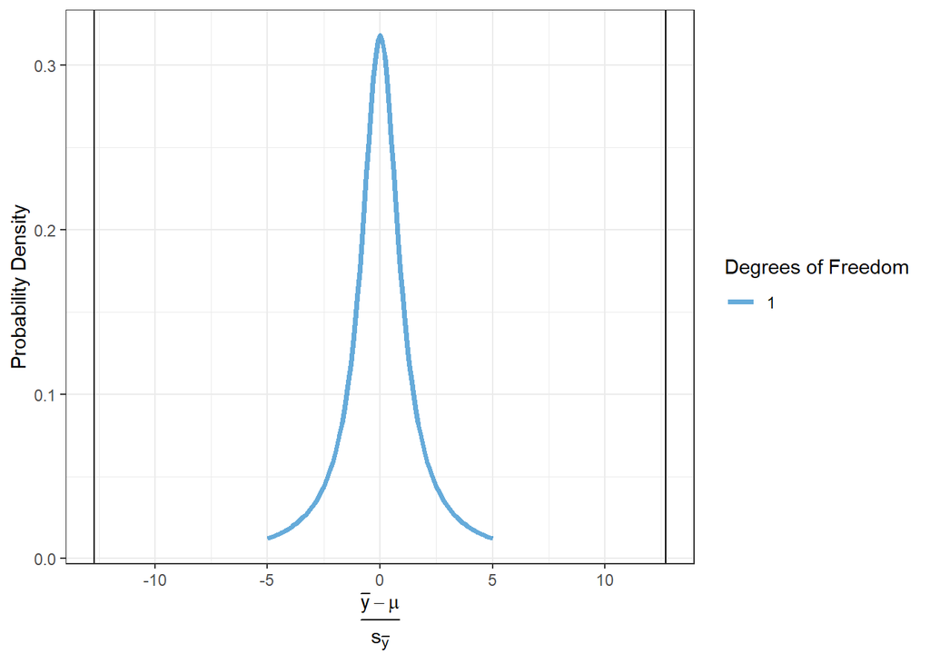

```r
n <- 2
df <- n - 1
lower_95 <- qt(p = 0.025,df = df)
upper_95 <- qt(p = 0.975,df = df)
tibble(Y = seq(-5,5, by = 0.1))|>expand_grid(df = df)|>mutate(Probability = dt(Y, df = df), df = as_factor(df))|>as_tibble()|>
  ggplot(aes(x = Y, y = Probability, color = df))+
  geom_line(linewidth = 1.25, alpha = 0.6)+
  scale_color_jco()+
  geom_vline(aes(xintercept = upper_95))+
  geom_vline(aes(xintercept = lower_95))+
  guides(color = guide_legend(title = "Degrees of Freedom", reverse = TRUE))+
  ylab("Probability Density")+xlab(expression(frac(bar(y) - mu, s[bar(y)])))+
  theme_bw()
```

Why are we so interested in 95% intervals for a statistic? Why 95?

### Interpretation

How do we interpret a confidence interval?

Consider that we are taking $\mu$ as a fixed, but unknown, population parameter. The CI then is *not* saying “there’s a 95% probability that $\mu$ is in the 95% confidence interval.” If it’s fixed, it’s either in the CI or it isn’t. Remember I’ve mentioned these statistics are about long run probabilities - given the assumptions of our inference, if we were to repeat our sampling over and over again, our confidence interval would contain $\mu$ 95% of the time (or, we’d be wrong 5% of the time).

Let’s take 100 samples of size n, draws from a known probability distribution, but treat it as unknown like we’re calculating statistics.

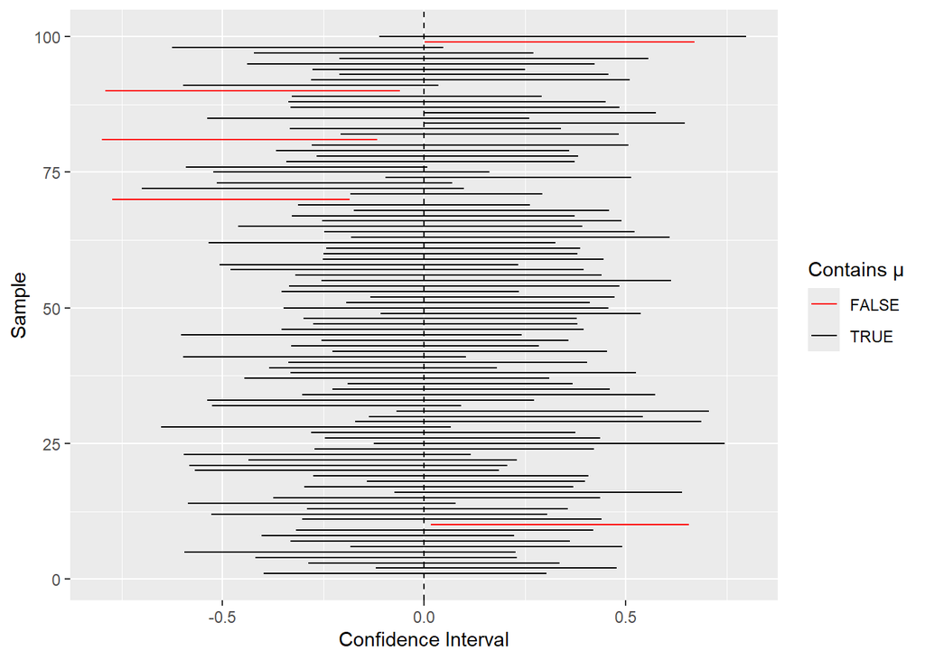

```r
set.seed(123)

# Known population parameters
mu <- 0
sigma <- 1
n <- 30

# Number of intervals
n_intervals <- 100

# Simulate data and build confidence intervals
results <- tibble(id = 1:n_intervals) %>%
  mutate(
    sample = map(id, ~ rnorm(n, mean = mu, sd = sigma)),
    sample_mean = map_dbl(sample, mean),
    sample_sd = map_dbl(sample, sd),
    se = sample_sd / sqrt(n),
    lower = sample_mean - 1.96 * se,
    upper = sample_mean + 1.96 * se,
    contains_mu = lower <= mu & upper >= mu
  )

results %>%
  ggplot(aes(y = id)) +
  geom_segment(aes(x = lower, xend = upper, yend = id,
                   color = contains_mu)) +
  geom_vline(xintercept = mu, linetype = "dashed") +
  scale_color_manual(values = c("red", "black")) +
  labs(
    x = "Confidence Interval",
    y = "Sample",
    color = "Contains μ"
  )
```

Can you use these methods to calculate a 95% confidence interval for a $\chi^2$ distribution?

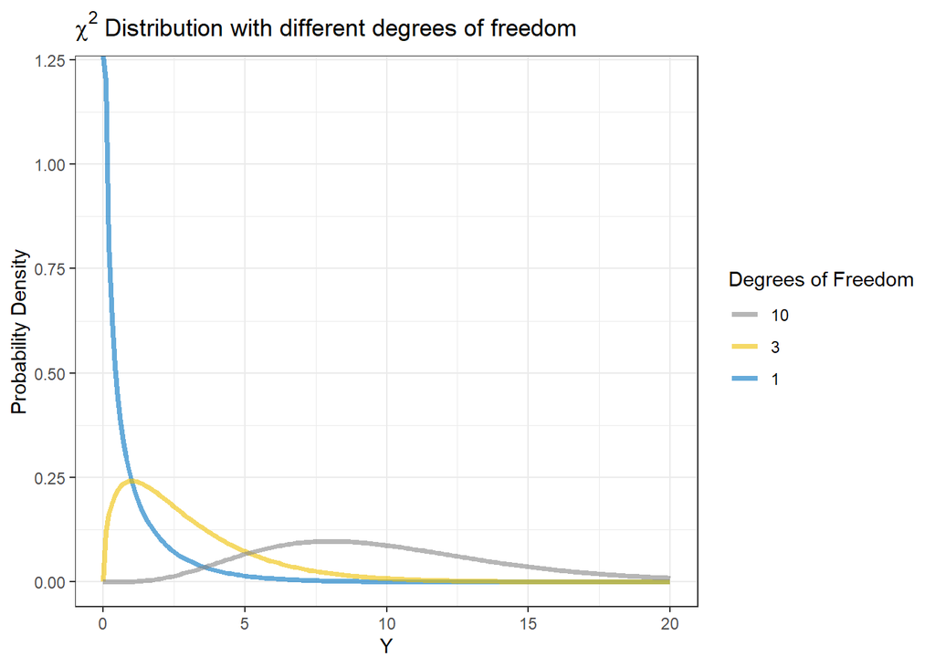

```r
tibble(Y = seq(0,20, by = 0.1))|>expand_grid(df = c(1,3,10))|>mutate(Probability = dchisq(Y, df = df), df = as_factor(df))|>as_tibble()|>
  ggplot(aes(x = Y, y = Probability, color = df))+
  geom_line(linewidth = 1.25, alpha = 0.6)+
  scale_color_jco()+
  guides(color = guide_legend(title = "Degrees of Freedom", reverse = TRUE))+
  ylab("Probability Density")+ggtitle(expression(chi^2 ~ "Distribution with different degrees of freedom"))+
  theme_bw()
```